# Introduction to Probability - Example 3.11

Example 3.11: Suppose that your company makes a headache medicine that is 60% effective. This means that when the drug is taken to cure a headache, it works 60% of the time. Someone in the company has proposed an additive that they think will make it more effective and is proposing that you run a test on 100 people to demonstrate efficacy. Your job is to determine how many people $M$ need to have their headaches cured to feel confident that the additive worked.

### Background information:

1. Type 1 error: Rejecting the null hypothesis when it’s true.
- To avoid this error, we need to pick a large enough number of cured headaches to be confident that it actually worked.
2. Type 2 error: Failing to reject the null hypothesis when it’s false.
- To avoid this error, we need to pick a small enough number of cured headaches so that we don’t make it unnecessarily difficult to prove that it works.

### Define the Hypothesis

- The Null Hypothesis ($H_0$): The medicine with additive is 60% effective.

### Phase 1: Rejecting the Null Hypothesis

We want to determine the probability that at least $m$ people are cured under the null hypothesis. This establishes what we might expect to see when the additive is ineffective. We want to pick $m$ large enough so that we can be reasonably confident that we’re seeing something different. We will set the standard at 95% confidence.

Here is the graph of the binomial distribution for $n = 100$ and $p = 0.6$. This shows the distribution of values we expect to see under the null hypothesis.

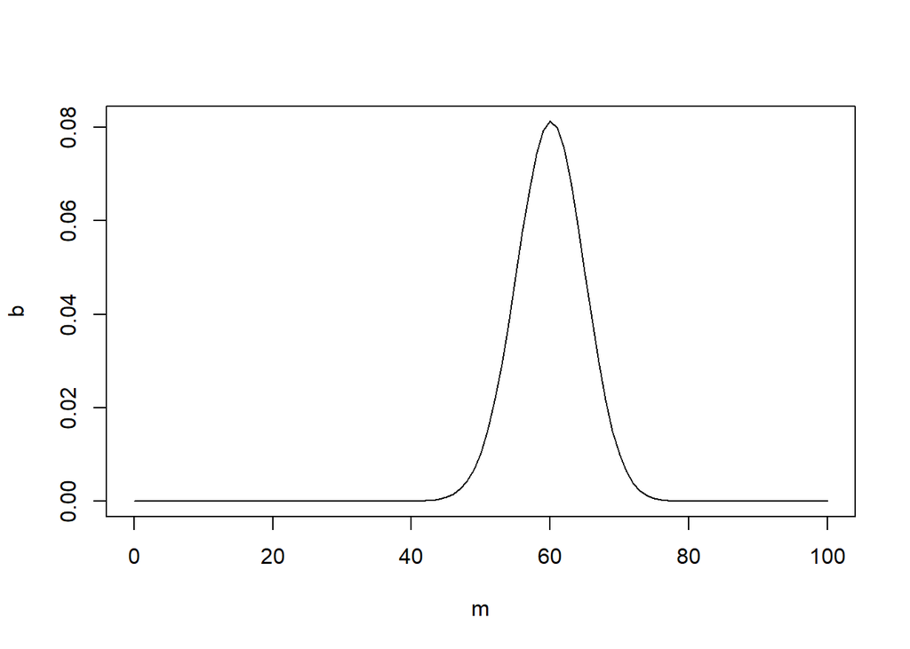

```r
n <- 100
p <- 0.6

m <- 0:100
b <- dbinom(m, n, p)

plot(m, b, type='l')
```

Here is the graph of the cumulative mass function. This shows us the probability that $m$ or fewer people were cured under the null hypothesis.

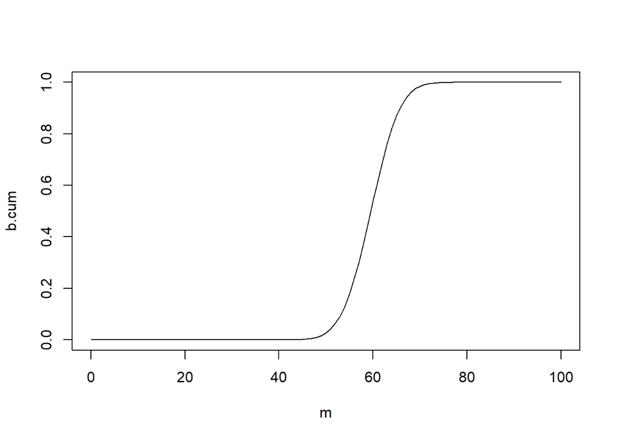

```r
b.cum <- cumsum(b)

plot(m, b.cum, type='l')
```

We want to see this number be higher than 0.95. This 95% confidence level just means that we want the result to be in the 95th percentile of possible outcomes under the null hypothesis.

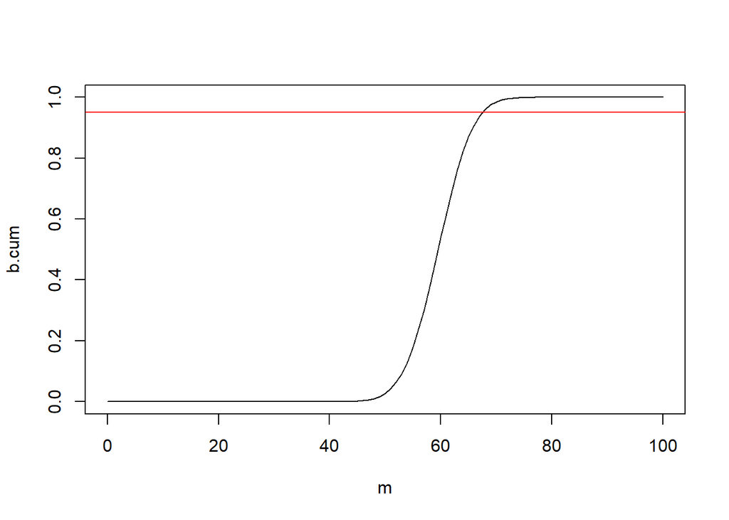

```r
b.cum <- cumsum(b)

plot(m, b.cum, type='l')
abline(0.95, 0, col = 'red')
```

We will zoom in on the important region to find the crossover point.

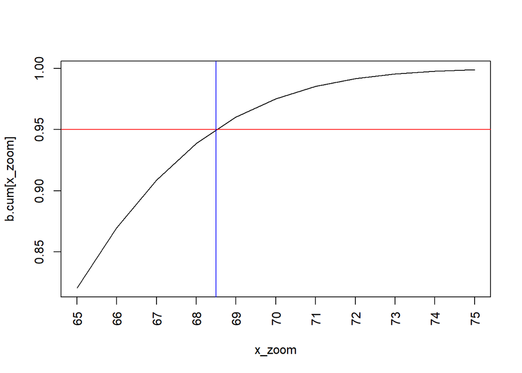

```r
x_zoom <- 65:75

plot(x_zoom, b.cum[x_zoom], type='l', xaxt='n')
axis(1, at=65:75, las=2)
abline(0.95, 0, col='red')
abline(v=68.5, col='blue')
```

This shows us that we want to have $M$ be at least 69.

### Phase 2: Setting an Upper Limit

We have shown that if at least 69 people are cured, then we should feel pretty confident that the drug is not effective at the 60% rate. We don’t know how much better it might be and whether it is worth pursuing.

After consulting with the company, it is determined that they would make the investment if they were 95% confident that the drug was 80% effective.

This gives us a new hypothesis to consider:

- Another Hypothesis ($H_1$): The medicine with additive is 80% effective.

Following the same pattern as before, here are the binomial and cumulative mass distributions.

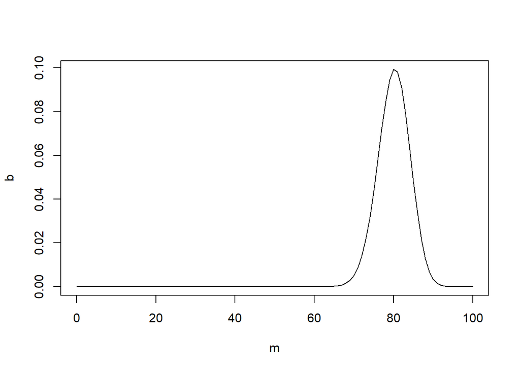

```r
n <- 100
p <- 0.8

m <- 0:100
b <- dbinom(m, n, p)

plot(m, b, type='l')
```

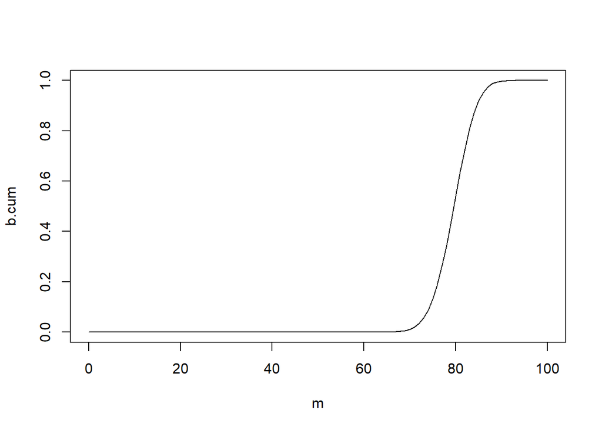

```r
b.cum <- cumsum(b)

plot(m, b.cum, type='l')
```

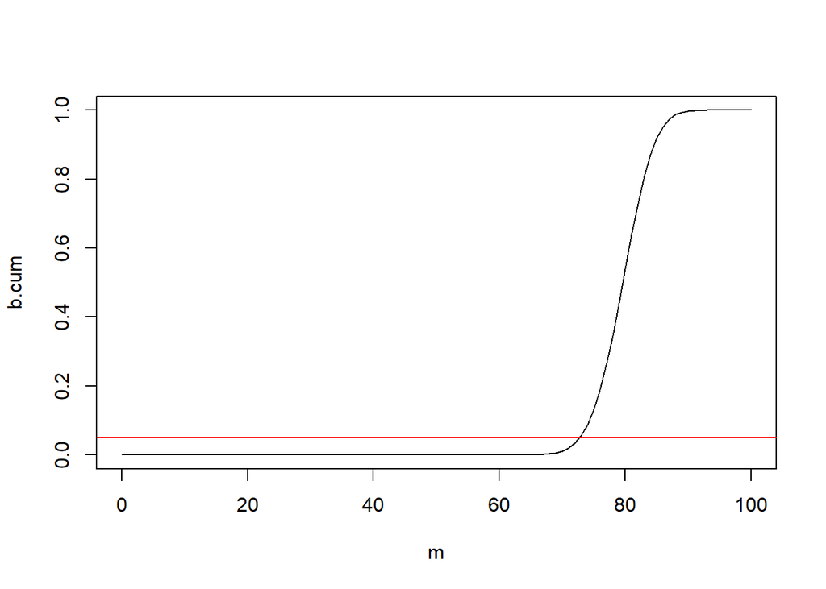

```r
b.cum <- cumsum(b)

plot(m, b.cum, type='l')
abline(0.05, 0, col = 'red')
```

We will zoom in on the important region to find the crossover point.

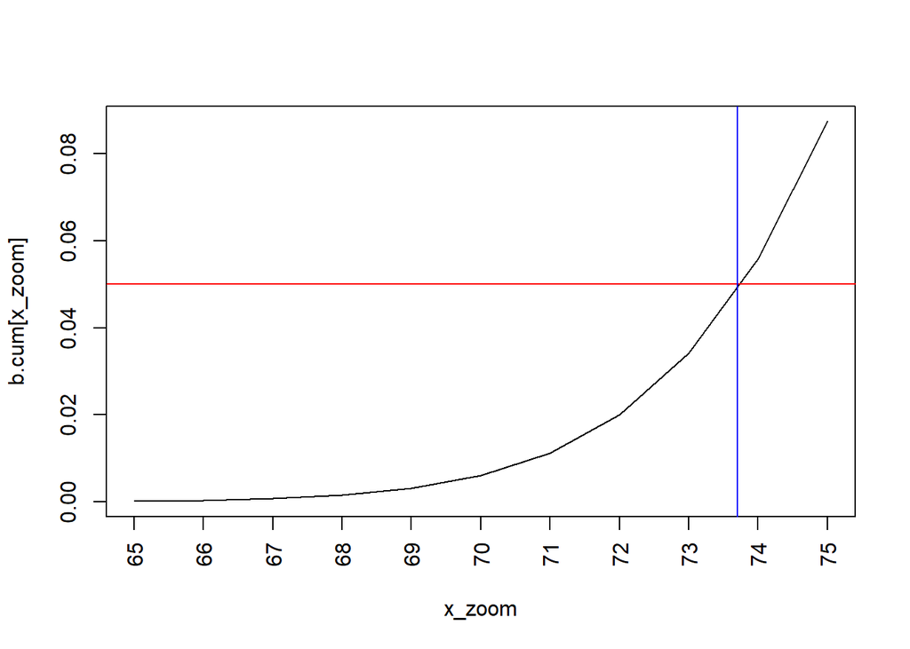

```r
x_zoom <- 65:75

plot(x_zoom, b.cum[x_zoom], type='l', xaxt='n')
axis(1, at=65:75, las=2)
abline(0.05, 0, col='red')
abline(v=73.7, col='blue')
```

### Conclusion

From Phase 1, we found that $m$ needed to be at least 69 for us to be 95% confident that the additive improved the effectiveness of the medicine.